# Lab 03

## Instructions

The format for this lab is similar to the last one. I have a section here which loads in various libraries (if some are new, there will also be code to install them) and then loads a dataset of interest. Your goal is to predict the value of the third column (which will be missing on the test set) using the techniques we have learned so far. In this case, please restrict yourself to linear regressions, though you may now use multivariate models.

The lab should be written as short code snippets with surrounding text. The text should be in full sentences and should fully describe what and why you are running the code you are running. When there are results, you should also give a sentence or two describing them.

Make sure to include at a minimum several plots and justify why are picked the final model you are using.

You may not share code with other students prior to the submission of each lab. However, discussing the labs amongst other students is allowed. Also, copying and pasting my code from class or prior submissions you made is **not** considered plagiarism and is in fact highly encouraged. With permission, I may occasionally post student-solutions to past labs. These are also fair game for copying code from (though please do not excessively copy the expository text). If in doubt, please ask me before submitting results.

## Set up

Your first step should be to read in the following libraries:

```r
library(readr)
library(dplyr)
```

```r
library(ggplot2)
library(viridis)
```

And to load the wine dataset:

```r
wine <- read_csv("https://statsmaths.github.io/ml_data/wine.csv")
```

The dataset gives characteristics of various types of wine. Your goal is to use these to estimate the quality of the wine.

Your code and text should go in the section below (feel free to create sub-sections with the `###` command at the start of line, though please note that this is not required):

## Lab 03

As we don’t know how to do much else at this point, fitting a model on all of the variables seems like a reasonable thing to do:

```r
model <- lm(quality ~ fixed_acidity + volatile_acidity + citric_acid +
                      residual_sugar + chlorides +
                      free_sulfur_dioxide + total_sulfur_dioxide +
                      density + ph + sulphates + alcohol + red,
            data = wine)
wine$quality_pred <- predict(model, newdata = wine)
```

The summary function will tell me roughly the important of each variable. The T-value in particular is a measurment of how strongly each variable effects the output.

```r
summary(model)
```

```
##
## Call:
## lm(formula = quality ~ fixed_acidity + volatile_acidity + citric_acid +
##     residual_sugar + chlorides + free_sulfur_dioxide + total_sulfur_dioxide +
##     density + ph + sulphates + alcohol + red, data = wine)
##
## Residuals:
##     Min      1Q  Median      3Q     Max
## -3.5105 -0.4679 -0.0405  0.4656  2.5040
##
## Coefficients:
##                        Estimate Std. Error t value Pr(>|t|)
## (Intercept)           9.482e+01  1.656e+01   5.725 1.10e-08 ***
## fixed_acidity         7.718e-02  1.875e-02   4.117 3.91e-05 ***
## volatile_acidity     -1.504e+00  9.909e-02 -15.180  < 2e-16 ***
## citric_acid          -7.918e-02  9.639e-02  -0.821    0.411
## residual_sugar        6.075e-02  7.096e-03   8.562  < 2e-16 ***
## chlorides            -4.992e-01  3.873e-01  -1.289    0.198
## free_sulfur_dioxide   5.341e-03  9.436e-04   5.660 1.61e-08 ***
## total_sulfur_dioxide -1.673e-03  3.937e-04  -4.249 2.19e-05 ***
## density              -9.440e+01  1.684e+01  -5.606 2.20e-08 ***
## ph                    5.104e-01  1.101e-01   4.637 3.65e-06 ***
## sulphates             6.562e-01  9.226e-02   7.113 1.32e-12 ***
## alcohol               2.397e-01  2.144e-02  11.176  < 2e-16 ***
## red                   3.476e-01  6.770e-02   5.134 2.96e-07 ***
## ---
## Signif. codes:  0 '***' 0.001 '**' 0.01 '*' 0.05 '.' 0.1 ' ' 1
##
## Residual standard error: 0.7309 on 4338 degrees of freedom
##   (2144 observations deleted due to missingness)
## Multiple R-squared:  0.2985, Adjusted R-squared:  0.2965
## F-statistic: 153.8 on 12 and 4338 DF,  p-value: < 2.2e-16
```

Only two variables have large p-values and are likely not degrading the fit. I looked at the distribution of all the numeric variables and did not notice anything that was a huge outlier (the `total_sulfur_dioxide` had some large values, but removing them did not improve the RMSE).

Looking at the variables with the highest T-value, there appears to be no obvious non-linearities where I should add higher order terms:

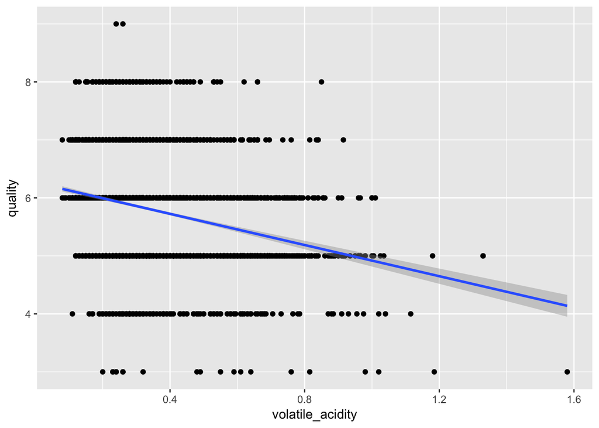

```r
qplot(volatile_acidity, quality, data = wine) +
  geom_smooth(method = "lm")
```

Here is the performance of my model on the training set:

```r
sqrt(mean((wine$quality_pred - wine$quality)^2, na.rm = TRUE))
```

```
## [1] 0.7298229
```

A fairly well-known trick is to shrink towards the grand mean. I’ll just do a factor of 0.01 here; without a validation set I cannot figure out the best shrinkage factor anyway:

```r
wine$quality_pred <- wine$quality_pred * 0.99 + mean(wine$quality_pred) * 0.01
sqrt(mean((wine$quality_pred - wine$quality)^2, na.rm = TRUE))
```

```
## [1] 0.7298385
```

It just barely makes the RMSE worse on my training set but may improve on the testing set.

## Submission

The code below assumes that you have adding a prediction named `quality_pred` to every row of the `wine` dataset.

```r
submit <- select(wine, obs_id, quality_pred)
write_csv(submit, "class03_submit.csv")
```

Now, upload this file (ends with “.Rmd”), the HTML output (ends with “.nb.html” or “.html”), and the csv file to GitHub.